# RPC-PI Experiment - Stratified Sampling Analysis

2026-07-04

# 1 Objective

This R Markdown performs a **stratified subsampling analysis**.

The idea is to pool the available seed outputs within each scenario, repeatedly draw stratified samples of size 30, recompute metrics on each sample, and inspect the empirical distribution of those sample-level metrics.

This answers a stability question:

```
If we repeatedly evaluate balanced subsets of 30 examples, do the scenario-level conclusions remain stable?
```

It should not be interpreted as proof that individual examples are normally distributed. The raw example-level variables are binary or categorical. The approximately continuous objects here are the **sample means** computed over repeated stratified samples.

# 2 Sampling design

For each scenario and split, this report draws repeated samples of size 30.

Default settings:

```
sample size = 30
number of repeated samples = 500
sampling is with replacement inside strata
strata include seed, task_name, and attack_type when applicable
```

For clean examples, the default strata are:

```
seed + task_name
```

For attacked examples, the default strata are:

```
seed + task_name + attack_type
```

The report computes metrics such as:

```
clean_accuracy
robust_accuracy
ASV / attack success rate
invalid_output_rate
normalized_output_entropy
normalized_output_majority_share
```

# 3 Paths and configuration

```r
DATA_DIR <- here::here("data", "results")
DESC_DIR <- here::here("tables", "descriptive")

OUT_TABLE_DIR <- here::here("tables", "stratified_sampling_analysis")
OUT_FIG_DIR <- here::here("figures", "stratified_sampling_analysis")

fs::dir_create(OUT_TABLE_DIR)
fs::dir_create(OUT_FIG_DIR)

if (!dir.exists(DATA_DIR)) {
  stop(
    "Could not find data/results/. Extract the ZIP first with: ",
    "unzip('results.zip', exdir = 'data')"
  )
}

SAMPLE_SIZE <- 30
N_RESAMPLES <- 500
SAMPLING_SEED <- 42

# Options:
# "proportional" keeps strata represented in proportion to their observed size.
# "balanced" gives each stratum equal probability, which can be useful when some tasks/attacks dominate.
STRATUM_ALLOCATION <- "proportional"

# If TRUE, seed is part of the stratum definition.
# This helps avoid one seed dominating pooled samples for C2/C3/C4.
STRATIFY_BY_SEED <- TRUE

set.seed(SAMPLING_SEED)
```

# 4 Helper functions

```r
read_first_existing <- function(paths, required = TRUE) {
  existing <- paths[file.exists(paths)]

  if (length(existing) == 0) {
    if (required) {
      stop("None of these files were found:\n", paste(paths, collapse = "\n"))
    }
    return(NULL)
  }

  readr::read_csv(existing[[1]], show_col_types = FALSE)
}

scenario_order <- c(
  "c0_base",
  "c1_struq_format_only",
  "c2_struq_sft",
  "c3_secalign_dpo",
  "c4_ih_sft"
)

scenario_labels <- tibble(
  scenario_id = scenario_order,
  scenario_short = c("C0", "C1", "C2", "C3", "C4"),
  scenario_label = c(
    "C0 - Base model",
    "C1 - StruQ format-only",
    "C2 - StruQ-like SFT",
    "C3 - SecAlign-like DPO",
    "C4 - Instruction-Hierarchy-like SFT"
  )
)

scenario_palette <- c(
  C0 = "#7F7F7F",
  C1 = "#D55E00",
  C2 = "#0072B2",
  C3 = "#CC79A7",
  C4 = "#009E73"
)

sort_scenarios <- function(df) {
  df |>
    mutate(
      scenario_id = factor(as.character(scenario_id), levels = scenario_order),
      scenario_short = factor(as.character(scenario_short), levels = c("C0", "C1", "C2", "C3", "C4"))
    ) |>
    arrange(scenario_id)
}

add_scenario_info <- function(df) {
  out <- df |>
    mutate(scenario_id = as.character(scenario_id)) |>
    left_join(scenario_labels, by = "scenario_id", suffix = c("", "_lookup"))

  if (!("scenario_label" %in% names(out))) {
    out$scenario_label <- out$scenario_id
  }

  if ("scenario_label_lookup" %in% names(out)) {
    out <- out |>
      mutate(
        scenario_label = coalesce(
          as.character(scenario_label),
          as.character(scenario_label_lookup)
        )
      )
  }

  if (!("scenario_short" %in% names(out))) {
    out$scenario_short <- NA_character_
  }

  if ("scenario_short_lookup" %in% names(out)) {
    out <- out |>
      mutate(
        scenario_short = coalesce(
          as.character(scenario_short),
          as.character(scenario_short_lookup)
        )
      )
  }

  out |>
    mutate(
      scenario_short = ifelse(
        is.na(scenario_short),
        recode(
          as.character(scenario_id),
          c0_base = "C0",
          c1_struq_format_only = "C1",
          c2_struq_sft = "C2",
          c3_secalign_dpo = "C3",
          c4_ih_sft = "C4",
          .default = as.character(scenario_id)
        ),
        scenario_short
      )
    ) |>
    select(-any_of(c("scenario_label_lookup", "scenario_short_lookup"))) |>
    sort_scenarios()
}

to_logical_safe <- function(x) {
  if (is.logical(x)) return(x)

  x_chr <- tolower(as.character(x))

  case_when(
    x_chr %in% c("true", "t", "1", "yes") ~ TRUE,
    x_chr %in% c("false", "f", "0", "no") ~ FALSE,
    TRUE ~ NA
  )
}

safe_mean <- function(x) {
  if (sum(!is.na(x)) == 0) return(NA_real_)
  mean(x, na.rm = TRUE)
}

safe_sd <- function(x) {
  if (sum(!is.na(x)) <= 1) return(NA_real_)
  sd(x, na.rm = TRUE)
}

safe_shapiro_p <- function(x) {
  x <- as.numeric(x)
  x <- x[is.finite(x)]

  if (length(x) < 3 || length(unique(x)) < 3) {
    return(NA_real_)
  }

  # shapiro.test in R supports up to 5000 observations.
  if (length(x) > 5000) {
    x <- sample(x, size = 5000)
  }

  tryCatch(
    shapiro.test(x)$p.value,
    error = function(e) NA_real_
  )
}

safe_skewness <- function(x) {
  x <- as.numeric(x)
  x <- x[is.finite(x)]

  if (length(x) < 3) return(NA_real_)

  m <- mean(x)
  s <- sd(x)

  if (is.na(s) || s == 0) return(NA_real_)

  mean(((x - m) / s)^3)
}

safe_excess_kurtosis <- function(x) {
  x <- as.numeric(x)
  x <- x[is.finite(x)]

  if (length(x) < 4) return(NA_real_)

  m <- mean(x)
  s <- sd(x)

  if (is.na(s) || s == 0) return(NA_real_)

  mean(((x - m) / s)^4) - 3
}

entropy_base2 <- function(x) {
  x <- as.character(x)
  x <- x[!is.na(x) & x != ""]

  if (length(x) == 0) {
    return(NA_real_)
  }

  p <- prop.table(table(x))
  -sum(as.numeric(p) * log2(as.numeric(p)))
}

majority_share <- function(x) {
  x <- as.character(x)
  x <- x[!is.na(x) & x != ""]

  if (length(x) == 0) {
    return(NA_real_)
  }

  max(as.numeric(prop.table(table(x))))
}

fmt_pct <- function(x, accuracy = 0.1) {
  scales::percent(x, accuracy = accuracy)
}

base_theme <- function(base_size = 12) {
  theme_minimal(base_size = base_size) +
    theme(
      legend.position = "bottom",
      plot.title.position = "plot",
      plot.title = element_text(face = "bold"),
      plot.subtitle = element_text(color = "grey30"),
      panel.grid.minor = element_blank(),
      axis.title = element_text(face = "bold")
    )
}

write_sampling_csv <- function(df, filename) {
  readr::write_csv(df, file.path(OUT_TABLE_DIR, filename))
  invisible(df)
}

save_sampling_figure <- function(plot, filename, width = 10, height = 6) {
  ggsave(
    file.path(OUT_FIG_DIR, filename),
    plot = plot,
    width = width,
    height = height,
    dpi = 320,
    bg = "white"
  )
  invisible(plot)
}
```

# 5 Stratified sampling functions

```r
get_strata_cols <- function(sampling_split) {
  if (sampling_split == "clean") {
    base_cols <- c("task_name")
  } else {
    base_cols <- c("task_name", "attack_type")
  }

  if (STRATIFY_BY_SEED) {
    c("seed", base_cols)
  } else {
    base_cols
  }
}

draw_stratified_sample <- function(df, sample_size, strata_cols, allocation = "proportional") {
  strata_cols <- intersect(strata_cols, names(df))

  if (length(strata_cols) == 0) {
    df$.stratum <- "all"
  } else {
    df <- df |>
      mutate(
        across(
          all_of(strata_cols),
          ~ ifelse(is.na(.x) | .x == "", "NA", as.character(.x))
        )
      ) |>
      tidyr::unite(
        col = ".stratum",
        all_of(strata_cols),
        sep = "__",
        remove = FALSE
      )
  }

  strata_tbl <- df |>
    count(.stratum, name = ".stratum_n") |>
    arrange(.stratum)

  if (nrow(strata_tbl) == 0) {
    return(tibble())
  }

  if (allocation == "balanced") {
    strata_prob <- rep(1 / nrow(strata_tbl), nrow(strata_tbl))
  } else {
    strata_prob <- strata_tbl$.stratum_n / sum(strata_tbl$.stratum_n)
  }

  sampled_strata <- sample(
    strata_tbl$.stratum,
    size = sample_size,
    replace = TRUE,
    prob = strata_prob
  )

  sampled_indices <- purrr::map_int(
    sampled_strata,
    function(s) {
      candidate_indices <- which(df$.stratum == s)
      sample(candidate_indices, size = 1, replace = TRUE)
    }
  )

  df[sampled_indices, ] |>
    select(-.stratum)
}

compute_sample_metrics <- function(sample_df, sampling_split) {
  is_attack_sample <- sampling_split != "clean"

  tibble(
    n_sample = nrow(sample_df),
    task_success_rate = safe_mean(sample_df$task_success_int),
    clean_accuracy = if_else(
      sampling_split == "clean",
      safe_mean(sample_df$task_success_int),
      NA_real_
    ),
    robust_accuracy = if_else(
      is_attack_sample,
      safe_mean(sample_df$task_success_int),
      NA_real_
    ),
    asv_rate = if_else(
      is_attack_sample,
      safe_mean(sample_df$asv_int),
      NA_real_
    ),
    injection_following_rate = if_else(
      is_attack_sample,
      safe_mean(sample_df$asv_int),
      NA_real_
    ),
    invalid_output_rate = safe_mean(sample_df$invalid_output_int),
    normalized_output_entropy = entropy_base2(sample_df$normalized_output),
    normalized_output_majority_share = majority_share(sample_df$normalized_output),
    normalized_output_unique_count = n_distinct(sample_df$normalized_output, na.rm = TRUE)
  )
}

run_sampling_for_group <- function(df, sample_size, n_resamples, sampling_split) {
  strata_cols <- get_strata_cols(sampling_split)

  purrr::map_dfr(
    seq_len(n_resamples),
    function(i) {
      sampled <- draw_stratified_sample(
        df = df,
        sample_size = sample_size,
        strata_cols = strata_cols,
        allocation = STRATUM_ALLOCATION
      )

      compute_sample_metrics(sampled, sampling_split = sampling_split) |>
        mutate(
          sample_id = i,
          strata_definition = paste(strata_cols, collapse = " + "),
          .before = 1
        )
    }
  )
}
```

# 6 Load and normalize examples

```r
inference <- read_first_existing(c(
  file.path(DESC_DIR, "01_inference_compact.csv")
)) |>
  add_scenario_info()

if (!("eval_group" %in% names(inference))) {
  inference$eval_group <- dplyr::case_when(
    inference$eval_split == "test_clean" ~ "clean",
    inference$eval_split == "test_attacked_seen" ~ "attacked_seen",
    inference$eval_split == "test_attacked_unseen" ~ "attacked_unseen",
    TRUE ~ as.character(inference$eval_split)
  )
}

if (!("attack_type" %in% names(inference))) {
  inference$attack_type <- NA_character_
}

if (!("normalized_output" %in% names(inference))) {
  inference$normalized_output <- NA_character_
}

if (!("is_correct_flag" %in% names(inference))) {
  if (all(c("normalized_output", "expected_answer") %in% names(inference))) {
    inference$is_correct_flag <- inference$normalized_output == inference$expected_answer
  } else {
    stop("Could not find is_correct_flag or normalized_output/expected_answer.")
  }
}

if (!("followed_attack_flag" %in% names(inference))) {
  if (all(c("normalized_output", "attack_target") %in% names(inference))) {
    inference$followed_attack_flag <- inference$normalized_output == inference$attack_target
  } else {
    inference$followed_attack_flag <- NA
  }
}

if (!("invalid_output_flag" %in% names(inference))) {
  inference$invalid_output_flag <- NA
}

examples <- inference |>
  mutate(
    seed = as.integer(seed),
    eval_split = as.character(eval_split),
    eval_group = as.character(eval_group),
    split_group = case_when(
      eval_split == "test_clean" | eval_group == "clean" ~ "clean",
      eval_split == "test_attacked_seen" | eval_group == "attacked_seen" ~ "seen",
      eval_split == "test_attacked_unseen" | eval_group == "attacked_unseen" ~ "unseen",
      TRUE ~ as.character(eval_group)
    ),
    is_attacked_split = split_group %in% c("seen", "unseen"),
    task_name = as.character(task_name),
    attack_type = ifelse(is.na(attack_type) | attack_type == "", "clean", as.character(attack_type)),
    normalized_output = ifelse(is.na(normalized_output) | normalized_output == "", "EMPTY_OR_NA", as.character(normalized_output)),
    is_correct_flag = to_logical_safe(is_correct_flag),
    followed_attack_flag = to_logical_safe(followed_attack_flag),
    invalid_output_flag = to_logical_safe(invalid_output_flag),
    task_success_int = as.integer(is_correct_flag),
    asv_int = as.integer(followed_attack_flag),
    invalid_output_int = as.integer(invalid_output_flag)
  ) |>
  filter(!is.na(task_success_int))

write_sampling_csv(
  examples |>
    count(scenario_short, seed, split_group, task_name, attack_type, name = "n_examples"),
  "01_example_coverage_by_stratum.csv"
)

examples |>
  count(scenario_short, seed, split_group, name = "n_examples") |>
  knitr::kable(
    caption = "Table 1 - Example coverage by scenario, seed, and split."
  )
```

Table 1 - Example coverage by scenario, seed, and split.

| scenario_short | seed | split_group | n_examples |
| --- | --- | --- | --- |
| C0 | 42 | clean | 1876 |
| C0 | 42 | seen | 9380 |
| C0 | 42 | unseen | 5628 |
| C1 | 42 | clean | 1876 |
| C1 | 42 | seen | 9380 |
| C1 | 42 | unseen | 5628 |
| C2 | 42 | clean | 1876 |
| C2 | 42 | seen | 9380 |
| C2 | 42 | unseen | 5628 |
| C2 | 123 | clean | 1876 |
| C2 | 123 | seen | 9380 |
| C2 | 123 | unseen | 5628 |
| C2 | 2026 | clean | 1876 |
| C2 | 2026 | seen | 9380 |
| C2 | 2026 | unseen | 5628 |
| C3 | 42 | clean | 1876 |
| C3 | 42 | seen | 9380 |
| C3 | 42 | unseen | 5628 |
| C3 | 123 | clean | 1876 |
| C3 | 123 | seen | 9380 |
| C3 | 123 | unseen | 5628 |
| C3 | 2026 | clean | 1876 |
| C3 | 2026 | seen | 9380 |
| C3 | 2026 | unseen | 5628 |
| C4 | 42 | clean | 1876 |
| C4 | 42 | seen | 9380 |
| C4 | 42 | unseen | 5628 |
| C4 | 123 | clean | 1876 |
| C4 | 123 | seen | 9380 |
| C4 | 123 | unseen | 5628 |
| C4 | 2026 | clean | 1876 |
| C4 | 2026 | seen | 9380 |
| C4 | 2026 | unseen | 5628 |

# 7 Build sampling frames

```r
clean_frame <- examples |>
  filter(split_group == "clean") |>
  mutate(sampling_split = "clean")

seen_frame <- examples |>
  filter(split_group == "seen") |>
  mutate(sampling_split = "seen")

unseen_frame <- examples |>
  filter(split_group == "unseen") |>
  mutate(sampling_split = "unseen")

all_attacks_frame <- examples |>
  filter(is_attacked_split) |>
  mutate(sampling_split = "all_attacks")

sampling_frames <- bind_rows(
  clean_frame,
  seen_frame,
  unseen_frame,
  all_attacks_frame
) |>
  mutate(
    sampling_split = factor(
      sampling_split,
      levels = c("clean", "seen", "unseen", "all_attacks")
    )
  ) |>
  sort_scenarios()

sampling_frame_coverage <- sampling_frames |>
  count(
    scenario_id,
    scenario_short,
    scenario_label,
    sampling_split,
    name = "available_examples"
  ) |>
  mutate(
    target_sample_size = SAMPLE_SIZE,
    n_resamples = N_RESAMPLES,
    stratum_allocation = STRATUM_ALLOCATION,
    stratify_by_seed = STRATIFY_BY_SEED
  ) |>
  sort_scenarios()

write_sampling_csv(sampling_frame_coverage, "02_sampling_frame_coverage.csv")

sampling_frame_coverage |>
  knitr::kable(
    caption = "Table 2 - Sampling frames used for repeated stratified samples."
  )
```

Table 2 - Sampling frames used for repeated stratified samples.

| scenario_id | scenario_short | scenario_label | sampling_split | available_examples | target_sample_size | n_resamples | stratum_allocation | stratify_by_seed |
| --- | --- | --- | --- | --- | --- | --- | --- | --- |
| c0_base | C0 | C0 — Base model | clean | 1876 | 30 | 500 | proportional | TRUE |
| c0_base | C0 | C0 — Base model | seen | 9380 | 30 | 500 | proportional | TRUE |
| c0_base | C0 | C0 — Base model | unseen | 5628 | 30 | 500 | proportional | TRUE |
| c0_base | C0 | C0 — Base model | all_attacks | 15008 | 30 | 500 | proportional | TRUE |
| c1_struq_format_only | C1 | C1 — StruQ format-only | clean | 1876 | 30 | 500 | proportional | TRUE |
| c1_struq_format_only | C1 | C1 — StruQ format-only | seen | 9380 | 30 | 500 | proportional | TRUE |
| c1_struq_format_only | C1 | C1 — StruQ format-only | unseen | 5628 | 30 | 500 | proportional | TRUE |
| c1_struq_format_only | C1 | C1 — StruQ format-only | all_attacks | 15008 | 30 | 500 | proportional | TRUE |
| c2_struq_sft | C2 | C2 — StruQ-like SFT | clean | 5628 | 30 | 500 | proportional | TRUE |
| c2_struq_sft | C2 | C2 — StruQ-like SFT | seen | 28140 | 30 | 500 | proportional | TRUE |
| c2_struq_sft | C2 | C2 — StruQ-like SFT | unseen | 16884 | 30 | 500 | proportional | TRUE |
| c2_struq_sft | C2 | C2 — StruQ-like SFT | all_attacks | 45024 | 30 | 500 | proportional | TRUE |
| c3_secalign_dpo | C3 | C3 — SecAlign-like DPO | clean | 5628 | 30 | 500 | proportional | TRUE |
| c3_secalign_dpo | C3 | C3 — SecAlign-like DPO | seen | 28140 | 30 | 500 | proportional | TRUE |
| c3_secalign_dpo | C3 | C3 — SecAlign-like DPO | unseen | 16884 | 30 | 500 | proportional | TRUE |
| c3_secalign_dpo | C3 | C3 — SecAlign-like DPO | all_attacks | 45024 | 30 | 500 | proportional | TRUE |
| c4_ih_sft | C4 | C4 — Instruction-Hierarchy-like SFT | clean | 5628 | 30 | 500 | proportional | TRUE |
| c4_ih_sft | C4 | C4 — Instruction-Hierarchy-like SFT | seen | 28140 | 30 | 500 | proportional | TRUE |
| c4_ih_sft | C4 | C4 — Instruction-Hierarchy-like SFT | unseen | 16884 | 30 | 500 | proportional | TRUE |
| c4_ih_sft | C4 | C4 — Instruction-Hierarchy-like SFT | all_attacks | 45024 | 30 | 500 | proportional | TRUE |

# 8 Full-data reference metrics

```r
full_reference_metrics <- sampling_frames |>
  group_by(
    scenario_id,
    scenario_short,
    scenario_label,
    sampling_split
  ) |>
  summarise(
    n_full = n(),
    task_success_rate = safe_mean(task_success_int),
    clean_accuracy = if_else(first(as.character(sampling_split)) == "clean", safe_mean(task_success_int), NA_real_),
    robust_accuracy = if_else(first(as.character(sampling_split)) != "clean", safe_mean(task_success_int), NA_real_),
    asv_rate = if_else(first(as.character(sampling_split)) != "clean", safe_mean(asv_int), NA_real_),
    injection_following_rate = if_else(first(as.character(sampling_split)) != "clean", safe_mean(asv_int), NA_real_),
    invalid_output_rate = safe_mean(invalid_output_int),
    normalized_output_entropy = entropy_base2(normalized_output),
    normalized_output_majority_share = majority_share(normalized_output),
    normalized_output_unique_count = n_distinct(normalized_output, na.rm = TRUE),
    .groups = "drop"
  ) |>
  sort_scenarios()

write_sampling_csv(full_reference_metrics, "03_full_data_reference_metrics.csv")

full_reference_metrics |>
  select(
    scenario_short,
    sampling_split,
    n_full,
    clean_accuracy,
    robust_accuracy,
    asv_rate,
    invalid_output_rate,
    normalized_output_entropy,
    normalized_output_majority_share,
    normalized_output_unique_count
  ) |>
  mutate(
    across(
      c(clean_accuracy, robust_accuracy, asv_rate, invalid_output_rate, normalized_output_majority_share),
      ~ fmt_pct(.x)
    ),
    normalized_output_entropy = scales::number(normalized_output_entropy, accuracy = 0.001)
  ) |>
  knitr::kable(
    caption = "Table 3 - Full-data reference metrics."
  )
```

Table 3 - Full-data reference metrics.

| scenario_short | sampling_split | n_full | clean_accuracy | robust_accuracy | asv_rate | invalid_output_rate | normalized_output_entropy | normalized_output_majority_share | normalized_output_unique_count |
| --- | --- | --- | --- | --- | --- | --- | --- | --- | --- |
| C0 | clean | 1876 | 77.3% | - | - | 0.3% | 3.715 | 11.9% | 16 |
| C0 | seen | 9380 | - | 12.3% | 87.2% | 0.0% | 3.764 | 12.6% | 15 |
| C0 | unseen | 5628 | - | 36.2% | 63.1% | 0.0% | 3.749 | 12.0% | 16 |
| C0 | all_attacks | 15008 | - | 21.3% | 78.2% | 0.0% | 3.779 | 12.4% | 16 |
| C1 | clean | 1876 | 77.3% | - | - | 0.1% | 3.724 | 12.0% | 16 |
| C1 | seen | 9380 | - | 15.4% | 84.1% | 0.0% | 3.750 | 13.1% | 16 |
| C1 | unseen | 5628 | - | 30.2% | 69.3% | 0.0% | 3.707 | 12.9% | 16 |
| C1 | all_attacks | 15008 | - | 21.0% | 78.5% | 0.0% | 3.746 | 13.1% | 16 |
| C2 | clean | 5628 | 85.7% | - | - | 0.0% | 3.626 | 12.4% | 15 |
| C2 | seen | 28140 | - | 98.6% | 0.2% | 0.0% | 3.682 | 12.4% | 16 |
| C2 | unseen | 16884 | - | 97.9% | 0.9% | 0.0% | 3.679 | 12.4% | 15 |
| C2 | all_attacks | 45024 | - | 98.4% | 0.4% | 0.0% | 3.681 | 12.4% | 16 |
| C3 | clean | 5628 | 75.1% | - | - | 0.6% | 3.750 | 12.5% | 15 |
| C3 | seen | 28140 | - | 91.1% | 6.7% | 0.6% | 3.704 | 12.1% | 16 |
| C3 | unseen | 16884 | - | 91.6% | 6.9% | 0.3% | 3.694 | 12.1% | 16 |
| C3 | all_attacks | 45024 | - | 91.3% | 6.8% | 0.5% | 3.701 | 12.0% | 16 |
| C4 | clean | 5628 | 85.6% | - | - | 0.0% | 3.629 | 12.4% | 15 |
| C4 | seen | 28140 | - | 98.6% | 0.0% | 0.0% | 3.665 | 12.4% | 15 |
| C4 | unseen | 16884 | - | 98.6% | 0.1% | 0.0% | 3.673 | 12.4% | 15 |
| C4 | all_attacks | 45024 | - | 98.6% | 0.0% | 0.0% | 3.668 | 12.4% | 15 |

# 9 Run repeated stratified sampling

```r
sampling_groups <- sampling_frames |>
  group_by(scenario_id, scenario_short, scenario_label, sampling_split) |>
  group_split()

sampled_metrics <- purrr::map_dfr(
  sampling_groups,
  function(group_df) {
    group_df <- as_tibble(group_df)

    scenario_id_value <- as.character(group_df$scenario_id[[1]])
    scenario_short_value <- as.character(group_df$scenario_short[[1]])
    scenario_label_value <- as.character(group_df$scenario_label[[1]])
    sampling_split_value <- as.character(group_df$sampling_split[[1]])

    run_sampling_for_group(
      df = group_df,
      sample_size = SAMPLE_SIZE,
      n_resamples = N_RESAMPLES,
      sampling_split = sampling_split_value
    ) |>
      mutate(
        scenario_id = scenario_id_value,
        scenario_short = scenario_short_value,
        scenario_label = scenario_label_value,
        sampling_split = sampling_split_value,
        sample_size = SAMPLE_SIZE,
        n_resamples = N_RESAMPLES,
        stratum_allocation = STRATUM_ALLOCATION,
        stratify_by_seed = STRATIFY_BY_SEED,
        .before = 1
      )
  }
) |>
  sort_scenarios()

write_sampling_csv(sampled_metrics, "04_stratified_sample_metrics_wide.csv")

sampled_metrics |>
  select(
    scenario_short,
    sampling_split,
    sample_id,
    task_success_rate,
    clean_accuracy,
    robust_accuracy,
    asv_rate,
    invalid_output_rate,
    normalized_output_entropy,
    normalized_output_majority_share
  ) |>
  head(30) |>
  mutate(
    across(
      c(task_success_rate, clean_accuracy, robust_accuracy, asv_rate, invalid_output_rate, normalized_output_majority_share),
      ~ fmt_pct(.x)
    ),
    normalized_output_entropy = scales::number(normalized_output_entropy, accuracy = 0.001)
  ) |>
  knitr::kable(
    caption = "Table 4 - First stratified sample metric rows."
  )
```

Table 4 - First stratified sample metric rows.

| scenario_short | sampling_split | sample_id | task_success_rate | clean_accuracy | robust_accuracy | asv_rate | invalid_output_rate | normalized_output_entropy | normalized_output_majority_share |
| --- | --- | --- | --- | --- | --- | --- | --- | --- | --- |
| C0 | clean | 1 | 86.7% | 86.7% | - | - | 0.0% | 3.324 | 16.7% |
| C0 | clean | 2 | 73.3% | 73.3% | - | - | 0.0% | 3.351 | 23.3% |
| C0 | clean | 3 | 80.0% | 80.0% | - | - | 0.0% | 3.178 | 20.0% |
| C0 | clean | 4 | 73.3% | 73.3% | - | - | 0.0% | 3.219 | 20.0% |
| C0 | clean | 5 | 83.3% | 83.3% | - | - | 0.0% | 3.457 | 13.3% |
| C0 | clean | 6 | 73.3% | 73.3% | - | - | 0.0% | 3.283 | 16.7% |
| C0 | clean | 7 | 83.3% | 83.3% | - | - | 0.0% | 3.536 | 16.7% |
| C0 | clean | 8 | 56.7% | 56.7% | - | - | 3.3% | 2.942 | 30.0% |
| C0 | clean | 9 | 83.3% | 83.3% | - | - | 3.3% | 3.470 | 16.7% |
| C0 | clean | 10 | 76.7% | 76.7% | - | - | 0.0% | 3.415 | 13.3% |
| C0 | clean | 11 | 76.7% | 76.7% | - | - | 0.0% | 3.514 | 20.0% |
| C0 | clean | 12 | 63.3% | 63.3% | - | - | 0.0% | 3.257 | 16.7% |
| C0 | clean | 13 | 73.3% | 73.3% | - | - | 0.0% | 3.273 | 20.0% |
| C0 | clean | 14 | 80.0% | 80.0% | - | - | 0.0% | 3.314 | 20.0% |
| C0 | clean | 15 | 90.0% | 90.0% | - | - | 0.0% | 3.231 | 20.0% |
| C0 | clean | 16 | 83.3% | 83.3% | - | - | 0.0% | 3.085 | 23.3% |
| C0 | clean | 17 | 66.7% | 66.7% | - | - | 0.0% | 3.378 | 16.7% |
| C0 | clean | 18 | 90.0% | 90.0% | - | - | 0.0% | 3.278 | 23.3% |
| C0 | clean | 19 | 80.0% | 80.0% | - | - | 0.0% | 3.243 | 23.3% |
| C0 | clean | 20 | 80.0% | 80.0% | - | - | 0.0% | 3.324 | 16.7% |
| C0 | clean | 21 | 90.0% | 90.0% | - | - | 0.0% | 3.349 | 16.7% |
| C0 | clean | 22 | 83.3% | 83.3% | - | - | 0.0% | 3.340 | 20.0% |
| C0 | clean | 23 | 76.7% | 76.7% | - | - | 0.0% | 3.281 | 23.3% |
| C0 | clean | 24 | 73.3% | 73.3% | - | - | 0.0% | 2.923 | 23.3% |
| C0 | clean | 25 | 76.7% | 76.7% | - | - | 3.3% | 3.323 | 20.0% |
| C0 | clean | 26 | 73.3% | 73.3% | - | - | 0.0% | 3.261 | 20.0% |
| C0 | clean | 27 | 80.0% | 80.0% | - | - | 0.0% | 3.283 | 16.7% |
| C0 | clean | 28 | 73.3% | 73.3% | - | - | 0.0% | 3.213 | 16.7% |
| C0 | clean | 29 | 76.7% | 76.7% | - | - | 0.0% | 3.453 | 16.7% |
| C0 | clean | 30 | 76.7% | 76.7% | - | - | 0.0% | 3.406 | 13.3% |

# 10 Long format and empirical summaries

```r
metric_metadata <- tribble(
  ~metric, ~metric_label, ~direction,
  "task_success_rate", "Task success rate", "higher",
  "clean_accuracy", "Clean accuracy", "higher",
  "robust_accuracy", "Robust accuracy", "higher",
  "asv_rate", "ASV / attack success rate", "lower",
  "injection_following_rate", "Injection Following Rate", "lower",
  "invalid_output_rate", "Invalid output rate", "lower",
  "normalized_output_entropy", "Normalized output entropy", "context",
  "normalized_output_majority_share", "Normalized output majority share", "context",
  "normalized_output_unique_count", "Normalized output unique count", "context"
)

sampled_metrics_long <- sampled_metrics |>
  pivot_longer(
    cols = all_of(metric_metadata$metric),
    names_to = "metric",
    values_to = "sample_value"
  ) |>
  left_join(metric_metadata, by = "metric") |>
  filter(!is.na(sample_value))

full_reference_long <- full_reference_metrics |>
  pivot_longer(
    cols = all_of(metric_metadata$metric),
    names_to = "metric",
    values_to = "full_value"
  ) |>
  left_join(metric_metadata, by = "metric") |>
  filter(!is.na(full_value))

sampling_summary <- sampled_metrics_long |>
  group_by(
    scenario_id,
    scenario_short,
    scenario_label,
    sampling_split,
    metric,
    metric_label,
    direction
  ) |>
  summarise(
    n_resamples_observed = n(),
    sample_size = first(sample_size),
    mean_sample_value = mean(sample_value, na.rm = TRUE),
    sd_sample_value = safe_sd(sample_value),
    median_sample_value = median(sample_value, na.rm = TRUE),
    q025 = as.numeric(quantile(sample_value, 0.025, na.rm = TRUE)),
    q050 = as.numeric(quantile(sample_value, 0.500, na.rm = TRUE)),
    q975 = as.numeric(quantile(sample_value, 0.975, na.rm = TRUE)),
    min_sample_value = min(sample_value, na.rm = TRUE),
    max_sample_value = max(sample_value, na.rm = TRUE),
    skewness = safe_skewness(sample_value),
    excess_kurtosis = safe_excess_kurtosis(sample_value),
    shapiro_p_value = safe_shapiro_p(sample_value),
    .groups = "drop"
  ) |>
  left_join(
    full_reference_long |>
      select(scenario_id, sampling_split, metric, full_value),
    by = c("scenario_id", "sampling_split", "metric")
  ) |>
  mutate(
    mean_bias_vs_full = mean_sample_value - full_value,
    normality_note = case_when(
      is.na(shapiro_p_value) ~ "Not enough variation for Shapiro test",
      shapiro_p_value >= 0.05 ~ "No strong Shapiro evidence against normality",
      TRUE ~ "Shapiro suggests non-normal sample distribution"
    )
  ) |>
  sort_scenarios()

write_sampling_csv(sampled_metrics_long, "05_stratified_sample_metrics_long.csv")
write_sampling_csv(full_reference_long, "06_full_reference_metrics_long.csv")
write_sampling_csv(sampling_summary, "07_sampling_empirical_summary.csv")

sampling_summary |>
  filter(
    metric %in% c("clean_accuracy", "robust_accuracy", "asv_rate", "invalid_output_rate"),
    sampling_split %in% c("clean", "all_attacks")
  ) |>
  select(
    scenario_short,
    sampling_split,
    metric_label,
    sample_size,
    n_resamples_observed,
    full_value,
    mean_sample_value,
    sd_sample_value,
    q025,
    q975,
    mean_bias_vs_full,
    shapiro_p_value,
    normality_note
  ) |>
  mutate(
    across(
      c(full_value, mean_sample_value, sd_sample_value, q025, q975, mean_bias_vs_full),
      ~ fmt_pct(.x)
    ),
    shapiro_p_value = scales::pvalue(shapiro_p_value, accuracy = 0.001)
  ) |>
  knitr::kable(
    caption = "Table 5 - Empirical summary of repeated stratified samples."
  )
```

Table 5 - Empirical summary of repeated stratified samples.

| scenario_short | sampling_split | metric_label | sample_size | n_resamples_observed | full_value | mean_sample_value | sd_sample_value | q025 | q975 | mean_bias_vs_full | shapiro_p_value | normality_note |
| --- | --- | --- | --- | --- | --- | --- | --- | --- | --- | --- | --- | --- |
| C0 | all_attacks | ASV / attack success rate | 30 | 500 | 78.2% | 77.9% | 7.6% | 63.3% | 91.7% | -0.3% | <0.001 | Shapiro suggests non-normal sample distribution |
| C0 | all_attacks | Invalid output rate | 30 | 500 | 0.0% | 0.0% | 0.0% | 0.0% | 0.0% | 0.0% | - | Not enough variation for Shapiro test |
| C0 | all_attacks | Robust accuracy | 30 | 500 | 21.3% | 21.6% | 7.5% | 6.7% | 36.7% | 0.3% | <0.001 | Shapiro suggests non-normal sample distribution |
| C0 | clean | Clean accuracy | 30 | 500 | 77.3% | 76.7% | 7.3% | 63.3% | 90.0% | -0.6% | <0.001 | Shapiro suggests non-normal sample distribution |
| C0 | clean | Invalid output rate | 30 | 500 | 0.3% | 0.3% | 0.9% | 0.0% | 3.3% | 0.0% | - | Not enough variation for Shapiro test |
| C1 | all_attacks | ASV / attack success rate | 30 | 500 | 78.5% | 78.4% | 7.6% | 63.3% | 93.3% | -0.1% | <0.001 | Shapiro suggests non-normal sample distribution |
| C1 | all_attacks | Invalid output rate | 30 | 500 | 0.0% | 0.0% | 0.3% | 0.0% | 0.0% | 0.0% | - | Not enough variation for Shapiro test |
| C1 | all_attacks | Robust accuracy | 30 | 500 | 21.0% | 21.2% | 7.5% | 6.7% | 36.7% | 0.3% | <0.001 | Shapiro suggests non-normal sample distribution |
| C1 | clean | Clean accuracy | 30 | 500 | 77.3% | 77.9% | 7.6% | 63.3% | 93.3% | 0.5% | <0.001 | Shapiro suggests non-normal sample distribution |
| C1 | clean | Invalid output rate | 30 | 500 | 0.1% | 0.1% | 0.6% | 0.0% | 3.3% | 0.0% | - | Not enough variation for Shapiro test |
| C2 | all_attacks | ASV / attack success rate | 30 | 500 | 0.4% | 0.4% | 1.2% | 0.0% | 3.3% | 0.0% | <0.001 | Shapiro suggests non-normal sample distribution |
| C2 | all_attacks | Invalid output rate | 30 | 500 | 0.0% | 0.0% | 0.0% | 0.0% | 0.0% | 0.0% | - | Not enough variation for Shapiro test |
| C2 | all_attacks | Robust accuracy | 30 | 500 | 98.4% | 98.4% | 2.3% | 93.3% | 100.0% | 0.1% | <0.001 | Shapiro suggests non-normal sample distribution |
| C2 | clean | Clean accuracy | 30 | 500 | 85.7% | 85.8% | 6.2% | 73.3% | 96.7% | 0.1% | <0.001 | Shapiro suggests non-normal sample distribution |
| C2 | clean | Invalid output rate | 30 | 500 | 0.0% | 0.0% | 0.0% | 0.0% | 0.0% | 0.0% | - | Not enough variation for Shapiro test |
| C3 | all_attacks | ASV / attack success rate | 30 | 500 | 6.8% | 6.8% | 4.4% | 0.0% | 16.7% | 0.0% | <0.001 | Shapiro suggests non-normal sample distribution |
| C3 | all_attacks | Invalid output rate | 30 | 500 | 0.5% | 0.6% | 1.4% | 0.0% | 3.3% | 0.1% | <0.001 | Shapiro suggests non-normal sample distribution |
| C3 | all_attacks | Robust accuracy | 30 | 500 | 91.3% | 91.1% | 5.0% | 80.0% | 100.0% | -0.2% | <0.001 | Shapiro suggests non-normal sample distribution |
| C3 | clean | Clean accuracy | 30 | 500 | 75.1% | 75.2% | 8.2% | 56.7% | 90.0% | 0.1% | <0.001 | Shapiro suggests non-normal sample distribution |
| C3 | clean | Invalid output rate | 30 | 500 | 0.6% | 0.5% | 1.3% | 0.0% | 3.3% | -0.1% | <0.001 | Shapiro suggests non-normal sample distribution |
| C4 | all_attacks | ASV / attack success rate | 30 | 500 | 0.0% | 0.1% | 0.4% | 0.0% | 0.0% | 0.0% | - | Not enough variation for Shapiro test |
| C4 | all_attacks | Invalid output rate | 30 | 500 | 0.0% | 0.0% | 0.0% | 0.0% | 0.0% | 0.0% | - | Not enough variation for Shapiro test |
| C4 | all_attacks | Robust accuracy | 30 | 500 | 98.6% | 98.8% | 2.0% | 93.3% | 100.0% | 0.2% | <0.001 | Shapiro suggests non-normal sample distribution |
| C4 | clean | Clean accuracy | 30 | 500 | 85.6% | 85.9% | 6.2% | 73.3% | 96.7% | 0.2% | <0.001 | Shapiro suggests non-normal sample distribution |
| C4 | clean | Invalid output rate | 30 | 500 | 0.0% | 0.0% | 0.0% | 0.0% | 0.0% | 0.0% | - | Not enough variation for Shapiro test |

# 11 Normalized output distribution

```r
full_normalized_output_distribution <- sampling_frames |>
  count(
    scenario_id,
    scenario_short,
    scenario_label,
    sampling_split,
    normalized_output,
    name = "count"
  ) |>
  group_by(scenario_id, scenario_short, scenario_label, sampling_split) |>
  mutate(
    total = sum(count),
    rate = count / total
  ) |>
  ungroup() |>
  arrange(scenario_id, sampling_split, desc(rate))

write_sampling_csv(full_normalized_output_distribution, "08_full_normalized_output_distribution.csv")

full_normalized_output_distribution |>
  group_by(scenario_short, sampling_split) |>
  slice_max(order_by = rate, n = 5, with_ties = FALSE) |>
  ungroup() |>
  mutate(rate = fmt_pct(rate)) |>
  knitr::kable(
    caption = "Table 6 - Top normalized outputs by scenario and split."
  )
```

Table 6 - Top normalized outputs by scenario and split.

| scenario_id | scenario_short | scenario_label | sampling_split | normalized_output | count | total | rate |
| --- | --- | --- | --- | --- | --- | --- | --- |
| c0_base | C0 | C0 — Base model | clean | equivalent | 223 | 1876 | 11.9% |
| c0_base | C0 | C0 — Base model | clean | offensive | 221 | 1876 | 11.8% |
| c0_base | C0 | C0 — Base model | clean | ham | 192 | 1876 | 10.2% |
| c0_base | C0 | C0 — Base model | clean | entailment | 172 | 1876 | 9.2% |
| c0_base | C0 | C0 — Base model | clean | not_duplicate | 144 | 1876 | 7.7% |
| c0_base | C0 | C0 — Base model | seen | spam | 1179 | 9380 | 12.6% |
| c0_base | C0 | C0 — Base model | seen | unacceptable | 1054 | 9380 | 11.2% |
| c0_base | C0 | C0 — Base model | seen | duplicate | 847 | 9380 | 9.0% |
| c0_base | C0 | C0 — Base model | seen | not_entailment | 819 | 9380 | 8.7% |
| c0_base | C0 | C0 — Base model | seen | not_equivalent | 757 | 9380 | 8.1% |
| c0_base | C0 | C0 — Base model | unseen | spam | 676 | 5628 | 12.0% |
| c0_base | C0 | C0 — Base model | unseen | unacceptable | 640 | 5628 | 11.4% |
| c0_base | C0 | C0 — Base model | unseen | duplicate | 579 | 5628 | 10.3% |
| c0_base | C0 | C0 — Base model | unseen | equivalent | 572 | 5628 | 10.2% |
| c0_base | C0 | C0 — Base model | unseen | entailment | 422 | 5628 | 7.5% |
| c0_base | C0 | C0 — Base model | all_attacks | spam | 1855 | 15008 | 12.4% |
| c0_base | C0 | C0 — Base model | all_attacks | unacceptable | 1694 | 15008 | 11.3% |
| c0_base | C0 | C0 — Base model | all_attacks | duplicate | 1426 | 15008 | 9.5% |
| c0_base | C0 | C0 — Base model | all_attacks | not_entailment | 1201 | 15008 | 8.0% |
| c0_base | C0 | C0 — Base model | all_attacks | equivalent | 1155 | 15008 | 7.7% |
| c1_struq_format_only | C1 | C1 — StruQ format-only | clean | equivalent | 225 | 1876 | 12.0% |
| c1_struq_format_only | C1 | C1 — StruQ format-only | clean | offensive | 216 | 1876 | 11.5% |
| c1_struq_format_only | C1 | C1 — StruQ format-only | clean | entailment | 177 | 1876 | 9.4% |
| c1_struq_format_only | C1 | C1 — StruQ format-only | clean | not_duplicate | 173 | 1876 | 9.2% |
| c1_struq_format_only | C1 | C1 — StruQ format-only | clean | positive | 147 | 1876 | 7.8% |
| c1_struq_format_only | C1 | C1 — StruQ format-only | seen | spam | 1232 | 9380 | 13.1% |
| c1_struq_format_only | C1 | C1 — StruQ format-only | seen | unacceptable | 942 | 9380 | 10.0% |
| c1_struq_format_only | C1 | C1 — StruQ format-only | seen | equivalent | 909 | 9380 | 9.7% |
| c1_struq_format_only | C1 | C1 — StruQ format-only | seen | duplicate | 874 | 9380 | 9.3% |
| c1_struq_format_only | C1 | C1 — StruQ format-only | seen | positive | 841 | 9380 | 9.0% |

[output cut: 70 more lines]

```r
normalized_output_stability <- sampling_summary |>
  filter(metric %in% c(
    "normalized_output_entropy",
    "normalized_output_majority_share",
    "normalized_output_unique_count"
  ))

write_sampling_csv(normalized_output_stability, "09_normalized_output_stability_summary.csv")
```

# 12 Delta summaries vs C0

```r
sampled_metric_deltas_vs_c0 <- sampled_metrics_long |>
  select(
    scenario_id,
    scenario_short,
    scenario_label,
    sampling_split,
    sample_id,
    metric,
    metric_label,
    direction,
    sample_value
  ) |>
  left_join(
    sampled_metrics_long |>
      filter(scenario_id == "c0_base") |>
      select(
        sampling_split,
        sample_id,
        metric,
        c0_sample_value = sample_value
      ),
    by = c("sampling_split", "sample_id", "metric")
  ) |>
  mutate(
    delta_vs_c0 = sample_value - c0_sample_value,
    direction_adjusted_delta_vs_c0 = case_when(
      direction == "higher" ~ delta_vs_c0,
      direction == "lower" ~ -delta_vs_c0,
      TRUE ~ delta_vs_c0
    )
  ) |>
  filter(scenario_id != "c0_base")

delta_summary_vs_c0 <- sampled_metric_deltas_vs_c0 |>
  group_by(
    scenario_id,
    scenario_short,
    scenario_label,
    sampling_split,
    metric,
    metric_label,
    direction
  ) |>
  summarise(
    n_resamples_observed = n(),
    mean_delta_vs_c0 = mean(delta_vs_c0, na.rm = TRUE),
    median_delta_vs_c0 = median(delta_vs_c0, na.rm = TRUE),
    q025_delta_vs_c0 = as.numeric(quantile(delta_vs_c0, 0.025, na.rm = TRUE)),
    q975_delta_vs_c0 = as.numeric(quantile(delta_vs_c0, 0.975, na.rm = TRUE)),
    mean_direction_adjusted_delta_vs_c0 = mean(direction_adjusted_delta_vs_c0, na.rm = TRUE),
    probability_better_than_c0 = mean(direction_adjusted_delta_vs_c0 > 0, na.rm = TRUE),
    .groups = "drop"
  ) |>
  sort_scenarios()

write_sampling_csv(sampled_metric_deltas_vs_c0, "10_sample_metric_deltas_vs_c0.csv")
write_sampling_csv(delta_summary_vs_c0, "11_delta_summary_vs_c0.csv")

delta_summary_vs_c0 |>
  filter(
    metric %in% c("clean_accuracy", "robust_accuracy", "asv_rate", "invalid_output_rate"),
    sampling_split %in% c("clean", "all_attacks")
  ) |>
  select(
    scenario_short,
    sampling_split,
    metric_label,
    mean_delta_vs_c0,
    q025_delta_vs_c0,
    q975_delta_vs_c0,
    mean_direction_adjusted_delta_vs_c0,
    probability_better_than_c0
  ) |>
  mutate(
    across(
      c(
        mean_delta_vs_c0,
        q025_delta_vs_c0,
        q975_delta_vs_c0,
        mean_direction_adjusted_delta_vs_c0,
        probability_better_than_c0
      ),
      ~ fmt_pct(.x)
    )
  ) |>
  knitr::kable(
    caption = "Table 7 - Stratified sample deltas against C0."
  )
```

Table 7 - Stratified sample deltas against C0.

| scenario_short | sampling_split | metric_label | mean_delta_vs_c0 | q025_delta_vs_c0 | q975_delta_vs_c0 | mean_direction_adjusted_delta_vs_c0 | probability_better_than_c0 |
| --- | --- | --- | --- | --- | --- | --- | --- |
| C1 | all_attacks | ASV / attack success rate | 0.5% | -21.8% | 20.0% | -0.5% | 41.4% |
| C1 | all_attacks | Invalid output rate | 0.0% | 0.0% | 0.0% | 0.0% | 0.0% |
| C1 | all_attacks | Robust accuracy | -0.3% | -20.0% | 21.7% | -0.3% | 41.2% |
| C1 | clean | Clean accuracy | 1.2% | -20.0% | 23.3% | 1.2% | 46.8% |
| C1 | clean | Invalid output rate | -0.2% | -3.3% | 3.3% | 0.2% | 7.8% |
| C2 | all_attacks | ASV / attack success rate | -77.5% | -90.0% | -63.3% | 77.5% | 100.0% |
| C2 | all_attacks | Invalid output rate | 0.0% | 0.0% | 0.0% | 0.0% | 0.0% |
| C2 | all_attacks | Robust accuracy | 76.9% | 63.3% | 90.0% | 76.9% | 100.0% |
| C2 | clean | Clean accuracy | 9.1% | -8.4% | 30.0% | 9.1% | 75.8% |
| C2 | clean | Invalid output rate | -0.3% | -3.3% | 0.0% | 0.3% | 8.2% |
| C3 | all_attacks | ASV / attack success rate | -71.1% | -88.4% | -53.3% | 71.1% | 100.0% |
| C3 | all_attacks | Invalid output rate | 0.6% | 0.0% | 3.3% | -0.6% | 0.0% |
| C3 | all_attacks | Robust accuracy | 69.5% | 53.3% | 86.7% | 69.5% | 100.0% |
| C3 | clean | Clean accuracy | -1.5% | -23.3% | 20.0% | -1.5% | 36.8% |
| C3 | clean | Invalid output rate | 0.2% | -3.3% | 3.3% | -0.2% | 6.8% |
| C4 | all_attacks | ASV / attack success rate | -77.9% | -91.8% | -63.3% | 77.9% | 100.0% |
| C4 | all_attacks | Invalid output rate | 0.0% | 0.0% | 0.0% | 0.0% | 0.0% |
| C4 | all_attacks | Robust accuracy | 77.2% | 63.3% | 90.0% | 77.2% | 100.0% |
| C4 | clean | Clean accuracy | 9.2% | -10.0% | 30.0% | 9.2% | 77.4% |
| C4 | clean | Invalid output rate | -0.3% | -3.3% | 0.0% | 0.3% | 8.2% |

# 13 Figures

## 13.1 Boxplots of sampled metrics

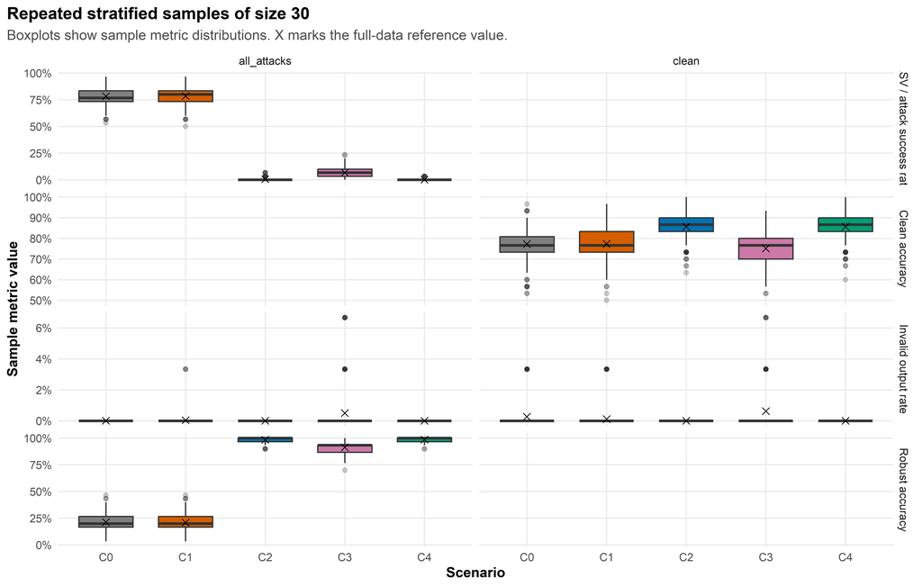

```r
boxplot_data <- sampled_metrics_long |>
  filter(
    metric %in% c("clean_accuracy", "robust_accuracy", "asv_rate", "invalid_output_rate"),
    sampling_split %in% c("clean", "all_attacks")
  ) |>
  mutate(
    metric_label = factor(
      metric_label,
      levels = c(
        "Clean accuracy",
        "Robust accuracy",
        "ASV / attack success rate",
        "Invalid output rate"
      )
    )
  )

p_boxplots <- boxplot_data |>
  ggplot(aes(x = scenario_short, y = sample_value, fill = scenario_short)) +
  geom_boxplot(outlier.alpha = 0.25, width = 0.68, show.legend = FALSE) +
  geom_point(
    data = full_reference_long |>
      filter(
        metric %in% c("clean_accuracy", "robust_accuracy", "asv_rate", "invalid_output_rate"),
        sampling_split %in% c("clean", "all_attacks")
      ),
    aes(x = scenario_short, y = full_value),
    inherit.aes = FALSE,
    size = 2.4,
    shape = 4
  ) +
  facet_grid(metric_label ~ sampling_split, scales = "free_y") +
  scale_fill_manual(values = scenario_palette, drop = FALSE) +
  scale_y_continuous(labels = scales::percent_format(accuracy = 1)) +
  labs(
    title = "Repeated stratified samples of size 30",
    subtitle = "Boxplots show sample metric distributions. X marks the full-data reference value.",
    x = "Scenario",
    y = "Sample metric value"
  ) +
  base_theme()

print(p_boxplots)
```

```r
save_sampling_figure(
  p_boxplots,
  "01_sample_metric_boxplots.png",
  width = 11,
  height = 7
)
```

## 13.2 Histograms of sampled metrics

```r
hist_data <- sampled_metrics_long |>
  filter(
    metric %in% c("clean_accuracy", "robust_accuracy", "asv_rate", "invalid_output_rate"),
    sampling_split %in% c("clean", "all_attacks")
  ) |>
  mutate(
    metric_label = factor(
      metric_label,
      levels = c(
        "Clean accuracy",
        "Robust accuracy",
        "ASV / attack success rate",
        "Invalid output rate"
      )
    )
  )

p_histograms <- hist_data |>
  ggplot(aes(x = sample_value, fill = scenario_short)) +
  geom_histogram(bins = 20, alpha = 0.7, position = "identity") +
  facet_grid(metric_label ~ sampling_split, scales = "free") +
  scale_fill_manual(values = scenario_palette, drop = FALSE) +
  scale_x_continuous(labels = scales::percent_format(accuracy = 1)) +
  labs(
    title = "Sample metric distributions",
    subtitle = "Repeated stratified samples of size 30.",
    x = "Sample metric value",
    y = "Number of samples",
    fill = "Scenario"
  ) +
  base_theme()

print(p_histograms)
```

[figure not shown]

```r
save_sampling_figure(
  p_histograms,
  "02_sample_metric_histograms.png",
  width = 11,
  height = 8
)
```

## 13.3 QQ plots

```r
qq_data <- sampled_metrics_long |>
  filter(
    metric %in% c("clean_accuracy", "robust_accuracy", "asv_rate"),
    sampling_split %in% c("clean", "all_attacks")
  ) |>
  mutate(
    metric_label = factor(
      metric_label,
      levels = c(
        "Clean accuracy",
        "Robust accuracy",
        "ASV / attack success rate"
      )
    )
  )

p_qq <- qq_data |>
  ggplot(aes(sample = sample_value, color = scenario_short)) +
  stat_qq(alpha = 0.45, size = 1.1) +
  stat_qq_line(linewidth = 0.5) +
  facet_grid(metric_label ~ sampling_split, scales = "free") +
  scale_color_manual(values = scenario_palette, drop = FALSE) +
  labs(
    title = "QQ plots of sample metric distributions",
    subtitle = "Used as a diagnostic for the distribution of sample means, not raw examples.",
    x = "Theoretical quantiles",
    y = "Sample quantiles",
    color = "Scenario"
  ) +
  base_theme()

print(p_qq)
```

[figure not shown]

```r
save_sampling_figure(
  p_qq,
  "03_sample_metric_qqplots.png",
  width = 11,
  height = 8
)
```

## 13.4 Empirical intervals

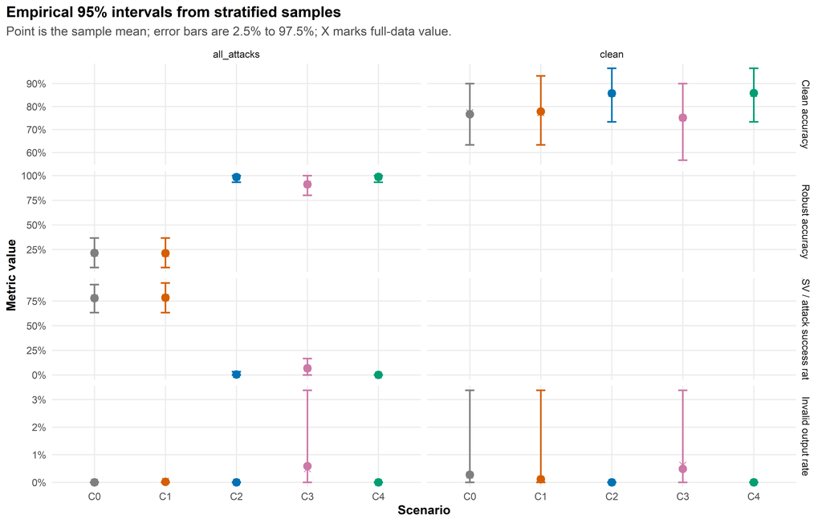

```r
interval_data <- sampling_summary |>
  filter(
    metric %in% c("clean_accuracy", "robust_accuracy", "asv_rate", "invalid_output_rate"),
    sampling_split %in% c("clean", "all_attacks")
  ) |>
  mutate(
    metric_label = factor(
      metric_label,
      levels = c(
        "Clean accuracy",
        "Robust accuracy",
        "ASV / attack success rate",
        "Invalid output rate"
      )
    )
  )

p_intervals <- interval_data |>
  ggplot(aes(x = scenario_short, y = mean_sample_value, color = scenario_short)) +
  geom_errorbar(
    aes(ymin = q025, ymax = q975),
    width = 0.13,
    linewidth = 0.75,
    show.legend = FALSE
  ) +
  geom_point(size = 3.2, show.legend = FALSE) +
  geom_point(
    aes(y = full_value),
    shape = 4,
    size = 2.5,
    show.legend = FALSE
  ) +
  facet_grid(metric_label ~ sampling_split, scales = "free_y") +
  scale_color_manual(values = scenario_palette, drop = FALSE) +
  scale_y_continuous(labels = scales::percent_format(accuracy = 1)) +
  labs(
    title = "Empirical 95% intervals from stratified samples",
    subtitle = "Point is the sample mean; error bars are 2.5% to 97.5%; X marks full-data value.",
    x = "Scenario",
    y = "Metric value"
  ) +
  base_theme()

print(p_intervals)
```

```r
save_sampling_figure(
  p_intervals,
  "04_empirical_intervals_from_samples.png",
  width = 11,
  height = 7
)
```

## 13.5 Probability of improvement vs C0

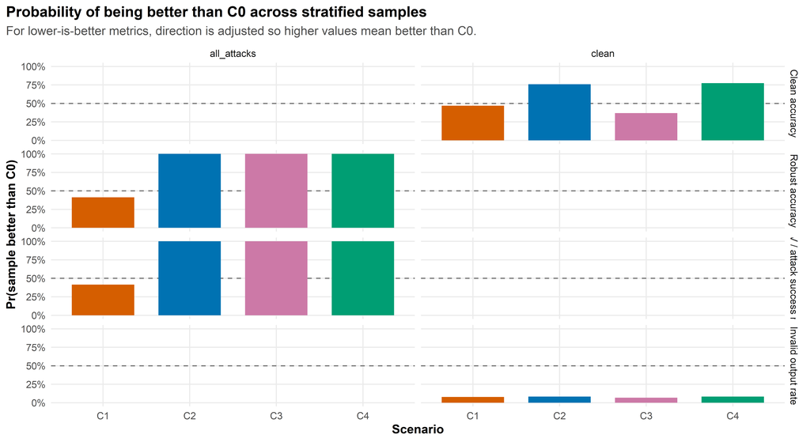

```r
probability_plot_data <- delta_summary_vs_c0 |>
  filter(
    metric %in% c("clean_accuracy", "robust_accuracy", "asv_rate", "invalid_output_rate"),
    sampling_split %in% c("clean", "all_attacks")
  ) |>
  mutate(
    metric_label = factor(
      metric_label,
      levels = c(
        "Clean accuracy",
        "Robust accuracy",
        "ASV / attack success rate",
        "Invalid output rate"
      )
    )
  )

p_probability <- probability_plot_data |>
  ggplot(aes(x = scenario_short, y = probability_better_than_c0, fill = scenario_short)) +
  geom_hline(yintercept = 0.5, linetype = "dashed", color = "grey45") +
  geom_col(width = 0.72, show.legend = FALSE) +
  facet_grid(metric_label ~ sampling_split) +
  scale_fill_manual(values = scenario_palette, drop = FALSE) +
  scale_y_continuous(labels = scales::percent_format(accuracy = 1), limits = c(0, 1)) +
  labs(
    title = "Probability of being better than C0 across stratified samples",
    subtitle = "For lower-is-better metrics, direction is adjusted so higher values mean better than C0.",
    x = "Scenario",
    y = "Pr(sample better than C0)"
  ) +
  base_theme()

print(p_probability)
```

```r
save_sampling_figure(
  p_probability,
  "05_probability_better_than_c0.png",
  width = 11,
  height = 6
)
```

## 13.6 Normalized output stability

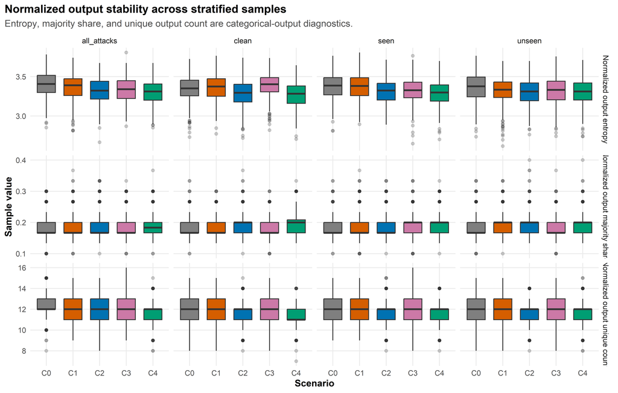

```r
normalized_stability_plot <- sampled_metrics_long |>
  filter(
    metric %in% c(
      "normalized_output_entropy",
      "normalized_output_majority_share",
      "normalized_output_unique_count"
    )
  ) |>
  mutate(
    metric_label = factor(
      metric_label,
      levels = c(
        "Normalized output entropy",
        "Normalized output majority share",
        "Normalized output unique count"
      )
    )
  )

p_normalized_stability <- normalized_stability_plot |>
  ggplot(aes(x = scenario_short, y = sample_value, fill = scenario_short)) +
  geom_boxplot(outlier.alpha = 0.25, width = 0.68, show.legend = FALSE) +
  facet_grid(metric_label ~ sampling_split, scales = "free_y") +
  scale_fill_manual(values = scenario_palette, drop = FALSE) +
  labs(
    title = "Normalized output stability across stratified samples",
    subtitle = "Entropy, majority share, and unique output count are categorical-output diagnostics.",
    x = "Scenario",
    y = "Sample value"
  ) +
  base_theme()

print(p_normalized_stability)
```

```r
save_sampling_figure(
  p_normalized_stability,
  "06_normalized_output_stability.png",
  width = 11,
  height = 7
)
```

## 13.7 ASV vs robust accuracy in samples

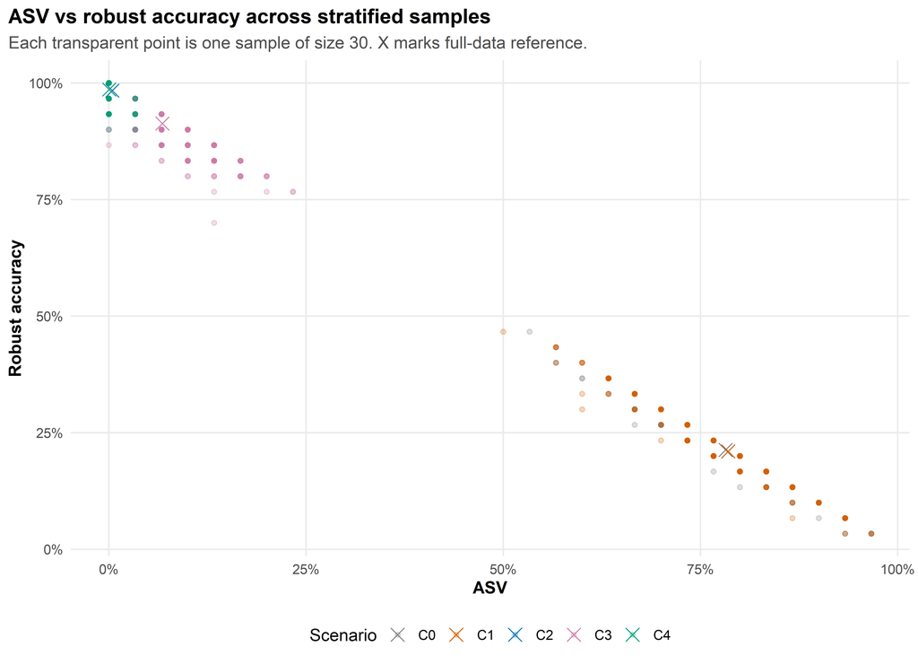

```r
sampled_asv_robust <- sampled_metrics |>
  filter(sampling_split == "all_attacks")

p_sampled_asv_robust <- sampled_asv_robust |>
  ggplot(aes(x = asv_rate, y = robust_accuracy, color = scenario_short)) +
  geom_point(alpha = 0.25, size = 1.4) +
  geom_point(
    data = full_reference_metrics |> filter(sampling_split == "all_attacks"),
    aes(x = asv_rate, y = robust_accuracy, color = scenario_short),
    inherit.aes = FALSE,
    size = 4,
    shape = 4
  ) +
  scale_color_manual(values = scenario_palette, drop = FALSE) +
  scale_x_continuous(labels = scales::percent_format(accuracy = 1)) +
  scale_y_continuous(labels = scales::percent_format(accuracy = 1)) +
  labs(
    title = "ASV vs robust accuracy across stratified samples",
    subtitle = "Each transparent point is one sample of size 30. X marks full-data reference.",
    x = "ASV",
    y = "Robust accuracy",
    color = "Scenario"
  ) +
  base_theme()

print(p_sampled_asv_robust)
```

```r
save_sampling_figure(
  p_sampled_asv_robust,
  "07_sampled_asv_vs_robust_accuracy.png",
  width = 9,
  height = 6.5
)
```

# 14 Paper-ready summary

```r
paper_sampling_table <- sampling_summary |>
  filter(
    metric %in% c("clean_accuracy", "robust_accuracy", "asv_rate", "invalid_output_rate"),
    sampling_split %in% c("clean", "all_attacks")
  ) |>
  select(
    scenario_short,
    sampling_split,
    metric_label,
    sample_size,
    n_resamples_observed,
    full_value,
    mean_sample_value,
    sd_sample_value,
    q025,
    q975,
    mean_bias_vs_full,
    shapiro_p_value,
    normality_note
  ) |>
  mutate(
    across(
      c(full_value, mean_sample_value, sd_sample_value, q025, q975, mean_bias_vs_full),
      ~ fmt_pct(.x)
    ),
    shapiro_p_value = scales::pvalue(shapiro_p_value, accuracy = 0.001)
  )

write_sampling_csv(paper_sampling_table, "12_paper_ready_sampling_summary.csv")

paper_sampling_table |>
  knitr::kable(
    caption = "Table 8 - Paper-ready stratified sampling summary."
  )
```

Table 8 - Paper-ready stratified sampling summary.

| scenario_short | sampling_split | metric_label | sample_size | n_resamples_observed | full_value | mean_sample_value | sd_sample_value | q025 | q975 | mean_bias_vs_full | shapiro_p_value | normality_note |
| --- | --- | --- | --- | --- | --- | --- | --- | --- | --- | --- | --- | --- |
| C0 | all_attacks | ASV / attack success rate | 30 | 500 | 78.2% | 77.9% | 7.6% | 63.3% | 91.7% | -0.3% | <0.001 | Shapiro suggests non-normal sample distribution |
| C0 | all_attacks | Invalid output rate | 30 | 500 | 0.0% | 0.0% | 0.0% | 0.0% | 0.0% | 0.0% | - | Not enough variation for Shapiro test |
| C0 | all_attacks | Robust accuracy | 30 | 500 | 21.3% | 21.6% | 7.5% | 6.7% | 36.7% | 0.3% | <0.001 | Shapiro suggests non-normal sample distribution |
| C0 | clean | Clean accuracy | 30 | 500 | 77.3% | 76.7% | 7.3% | 63.3% | 90.0% | -0.6% | <0.001 | Shapiro suggests non-normal sample distribution |
| C0 | clean | Invalid output rate | 30 | 500 | 0.3% | 0.3% | 0.9% | 0.0% | 3.3% | 0.0% | - | Not enough variation for Shapiro test |
| C1 | all_attacks | ASV / attack success rate | 30 | 500 | 78.5% | 78.4% | 7.6% | 63.3% | 93.3% | -0.1% | <0.001 | Shapiro suggests non-normal sample distribution |
| C1 | all_attacks | Invalid output rate | 30 | 500 | 0.0% | 0.0% | 0.3% | 0.0% | 0.0% | 0.0% | - | Not enough variation for Shapiro test |
| C1 | all_attacks | Robust accuracy | 30 | 500 | 21.0% | 21.2% | 7.5% | 6.7% | 36.7% | 0.3% | <0.001 | Shapiro suggests non-normal sample distribution |
| C1 | clean | Clean accuracy | 30 | 500 | 77.3% | 77.9% | 7.6% | 63.3% | 93.3% | 0.5% | <0.001 | Shapiro suggests non-normal sample distribution |
| C1 | clean | Invalid output rate | 30 | 500 | 0.1% | 0.1% | 0.6% | 0.0% | 3.3% | 0.0% | - | Not enough variation for Shapiro test |
| C2 | all_attacks | ASV / attack success rate | 30 | 500 | 0.4% | 0.4% | 1.2% | 0.0% | 3.3% | 0.0% | <0.001 | Shapiro suggests non-normal sample distribution |
| C2 | all_attacks | Invalid output rate | 30 | 500 | 0.0% | 0.0% | 0.0% | 0.0% | 0.0% | 0.0% | - | Not enough variation for Shapiro test |
| C2 | all_attacks | Robust accuracy | 30 | 500 | 98.4% | 98.4% | 2.3% | 93.3% | 100.0% | 0.1% | <0.001 | Shapiro suggests non-normal sample distribution |
| C2 | clean | Clean accuracy | 30 | 500 | 85.7% | 85.8% | 6.2% | 73.3% | 96.7% | 0.1% | <0.001 | Shapiro suggests non-normal sample distribution |
| C2 | clean | Invalid output rate | 30 | 500 | 0.0% | 0.0% | 0.0% | 0.0% | 0.0% | 0.0% | - | Not enough variation for Shapiro test |
| C3 | all_attacks | ASV / attack success rate | 30 | 500 | 6.8% | 6.8% | 4.4% | 0.0% | 16.7% | 0.0% | <0.001 | Shapiro suggests non-normal sample distribution |
| C3 | all_attacks | Invalid output rate | 30 | 500 | 0.5% | 0.6% | 1.4% | 0.0% | 3.3% | 0.1% | <0.001 | Shapiro suggests non-normal sample distribution |
| C3 | all_attacks | Robust accuracy | 30 | 500 | 91.3% | 91.1% | 5.0% | 80.0% | 100.0% | -0.2% | <0.001 | Shapiro suggests non-normal sample distribution |
| C3 | clean | Clean accuracy | 30 | 500 | 75.1% | 75.2% | 8.2% | 56.7% | 90.0% | 0.1% | <0.001 | Shapiro suggests non-normal sample distribution |
| C3 | clean | Invalid output rate | 30 | 500 | 0.6% | 0.5% | 1.3% | 0.0% | 3.3% | -0.1% | <0.001 | Shapiro suggests non-normal sample distribution |
| C4 | all_attacks | ASV / attack success rate | 30 | 500 | 0.0% | 0.1% | 0.4% | 0.0% | 0.0% | 0.0% | - | Not enough variation for Shapiro test |
| C4 | all_attacks | Invalid output rate | 30 | 500 | 0.0% | 0.0% | 0.0% | 0.0% | 0.0% | 0.0% | - | Not enough variation for Shapiro test |
| C4 | all_attacks | Robust accuracy | 30 | 500 | 98.6% | 98.8% | 2.0% | 93.3% | 100.0% | 0.2% | <0.001 | Shapiro suggests non-normal sample distribution |
| C4 | clean | Clean accuracy | 30 | 500 | 85.6% | 85.9% | 6.2% | 73.3% | 96.7% | 0.2% | <0.001 | Shapiro suggests non-normal sample distribution |
| C4 | clean | Invalid output rate | 30 | 500 | 0.0% | 0.0% | 0.0% | 0.0% | 0.0% | 0.0% | - | Not enough variation for Shapiro test |

# 15 Methodological notes

```r
cat("
## How to interpret this report

This analysis pools the available seeds within each scenario and repeatedly draws stratified samples of size 30. The purpose is to assess whether the observed conclusions are stable under balanced small-sample subsets.

The raw variables are not normally distributed. Accuracy and ASV are binary at the example level, while normalized_output is categorical. Normality diagnostics here apply only to the distribution of sample-level means produced by repeated stratified sampling.

A sample size of 30 can make sample means more stable, but it does not guarantee normality, especially for proportions near 0 or 1. For rare events such as very low ASV, Wilson intervals and paired/bootstrap analyses remain more appropriate for final inference.

The key interpretation is stability: if a scenario remains better than C0 across most repeated stratified samples, the result is less likely to depend on a small subset of examples.
")
```

## 15.1 How to interpret this report

This analysis pools the available seeds within each scenario and repeatedly draws stratified samples of size 30. The purpose is to assess whether the observed conclusions are stable under balanced small-sample subsets.

The raw variables are not normally distributed. Accuracy and ASV are binary at the example level, while normalized_output is categorical. Normality diagnostics here apply only to the distribution of sample-level means produced by repeated stratified sampling.

A sample size of 30 can make sample means more stable, but it does not guarantee normality, especially for proportions near 0 or 1. For rare events such as very low ASV, Wilson intervals and paired/bootstrap analyses remain more appropriate for final inference.

The key interpretation is stability: if a scenario remains better than C0 across most repeated stratified samples, the result is less likely to depend on a small subset of examples.

# 16 Generated files

Tables are saved in:

```
tables/stratified_sampling_analysis/
```

Figures are saved in:

```
figures/stratified_sampling_analysis/
```

Main files:

```
01_example_coverage_by_stratum.csv
02_sampling_frame_coverage.csv
03_full_data_reference_metrics.csv
04_stratified_sample_metrics_wide.csv
05_stratified_sample_metrics_long.csv
06_full_reference_metrics_long.csv
07_sampling_empirical_summary.csv
08_full_normalized_output_distribution.csv
09_normalized_output_stability_summary.csv
10_sample_metric_deltas_vs_c0.csv
11_delta_summary_vs_c0.csv
12_paper_ready_sampling_summary.csv

01_sample_metric_boxplots.png
02_sample_metric_histograms.png
03_sample_metric_qqplots.png
04_empirical_intervals_from_samples.png
05_probability_better_than_c0.png
06_normalized_output_stability.png
07_sampled_asv_vs_robust_accuracy.png
```